# Syntax Tugas Kelompok

Kelompok 4

# Library

```r
library(dplyr)
library(forecast)
library(lmtest)
library(orcutt)
library(HoRM)
```

```r
library(corrplot)
library(dLagM)
library(dynlm)
library(MLmetrics)
library(ggplot2)
library(tsibble)
library(tseries)
library(MASS)
library(aTSA)
library(nortest)
library(TSA)
library(TTR)
library(graphics)
```

# Input Data

```r
library(rio)
data <- rio::import("https://raw.githubusercontent.com/reyndpasaribu/MPDW/main/TUKEL/datal.csv")
data
```

```
##     Periode  Suhu
## 1         1 26.26
## 2         2 26.89
## 3         3 26.81
## 4         4 27.17
## 5         5 27.08
## 6         6 26.30
## 7         7 26.05
## 8         8 26.11
## 9         9 26.45
## 10       10 26.12
## 11       11 26.09
## 12       12 25.41
## 13       13 25.55
## 14       14 25.91
```

[output cut: 142 more lines]

### Ubah Menjadi Data Time Series

```r
data.ts <- ts(data$Suhu)
data.ts
```

```
## Time Series:
## Start = 1
## End = 156
## Frequency = 1
##   [1] 26.26 26.89 26.81 27.17 27.08 26.30 26.05 26.11 26.45 26.12 26.09 25.41
##  [13] 25.55 25.91 25.79 26.31 26.53 26.33 26.27 27.08 27.58 27.40 27.46 27.04
##  [25] 26.09 26.36 26.19 26.26 26.90 26.45 26.75 27.44 27.43 27.42 27.44 26.51
##  [37] 25.99 26.16 26.83 26.58 26.71 26.39 25.77 25.98 26.78 27.04 26.29 26.15
##  [49] 25.80 25.97 26.65 26.55 26.95 26.58 26.39 26.64 27.70 28.37 27.29 26.21
##  [61] 26.00 26.15 26.41 26.55 26.59 26.24 26.48 27.25 27.73 28.49 28.74 27.21
##  [73] 27.26 26.83 27.30 27.16 27.23 26.73 26.47 26.54 26.74 26.25 26.65 26.33
##  [85] 26.18 25.96 26.38 26.40 26.83 26.38 26.15 26.59 27.74 27.39 27.08 26.41
##  [97] 26.15 26.19 26.40 26.79 26.79 26.44 25.76 26.69 27.30 28.15 27.25 26.94
## [109] 26.85 26.87 26.72 27.17 26.95 26.23 26.04 26.76 27.87 28.30 28.48 28.26
## [121] 27.01 26.91 27.00 27.18 27.12 26.52 26.06 26.20 26.49 26.53 27.00 26.23
## [133] 26.19 26.30 26.39 26.55 27.01 26.40 26.29 26.88 26.78 27.15 26.43 26.54
## [145] 26.30 26.27 26.59 26.70 26.76 26.01 26.38 26.44 26.38 26.30 26.35 26.32
```

# Eksplorasi Data

#### Plot Data Penuh

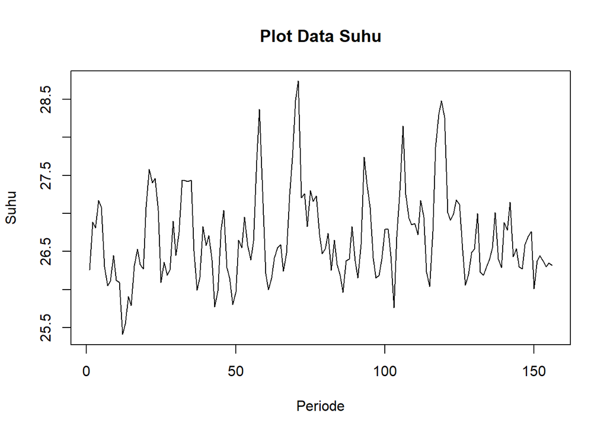

```r
plot.ts(data.ts, lty=1, xlab="Periode", ylab="Suhu", main="Plot Data Suhu")
```

Selanjutnya, akan dilakukan pembagian data latih dan data uji dengan proporsi 80%:20%.

#### Proporsi Data Latih dan Data Uji

```r
datatrain <- data.ts[1:125]
train.ts <- ts(datatrain)

datatest<-data.ts[126:156]
test.ts<-ts(datatest)
```

Berdasarkan plot data deret waktu pada data latih, terlihat bahwa data cenderung stasioner dan bergerak pada nilai tengah tertentu. Hal ini mengindikasikan bahwa data stasioner dalam rataan.

### Plot data

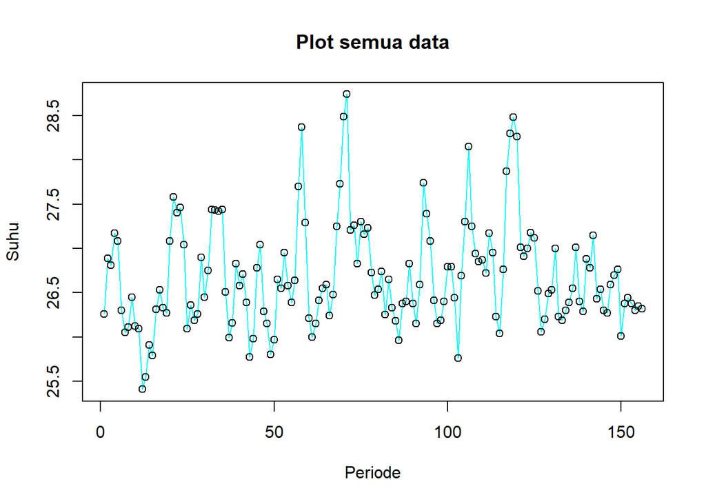

```r
# Semua Data
ts.plot(data.ts, col="cyan",main="Plot semua data", type="o",xlab="Periode",ylab="Suhu")
points(data.ts)
```

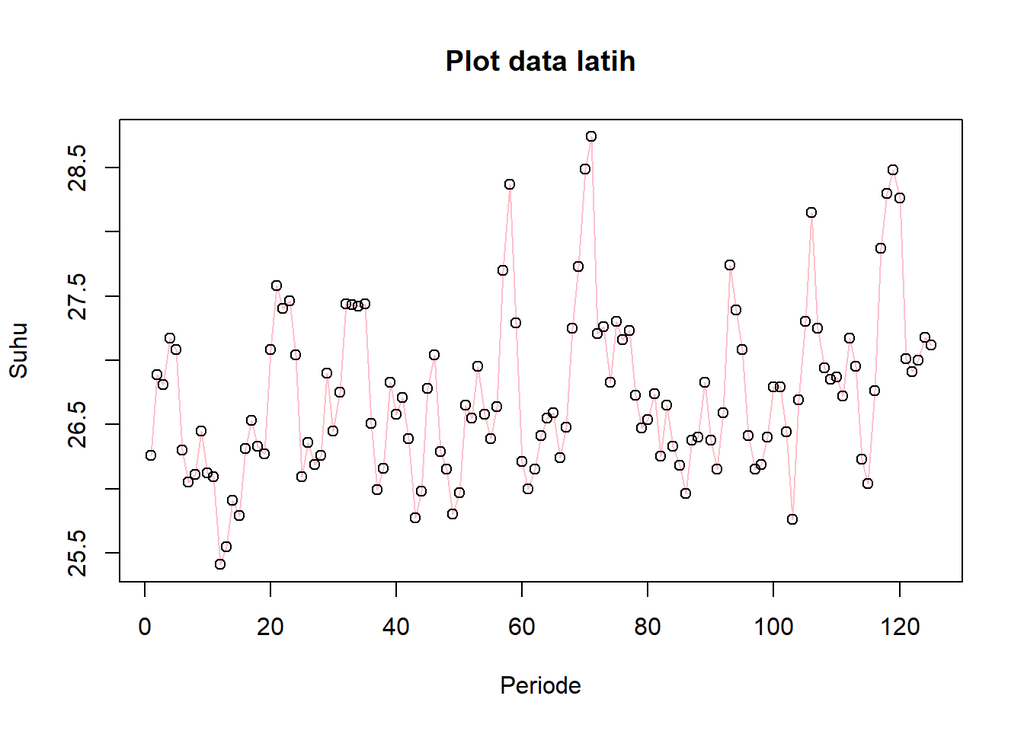

```r
# Data Train
ts.plot(train.ts, col="pink",main="Plot data latih", type="o",xlab="Periode",ylab="Suhu")
points(train.ts)
```

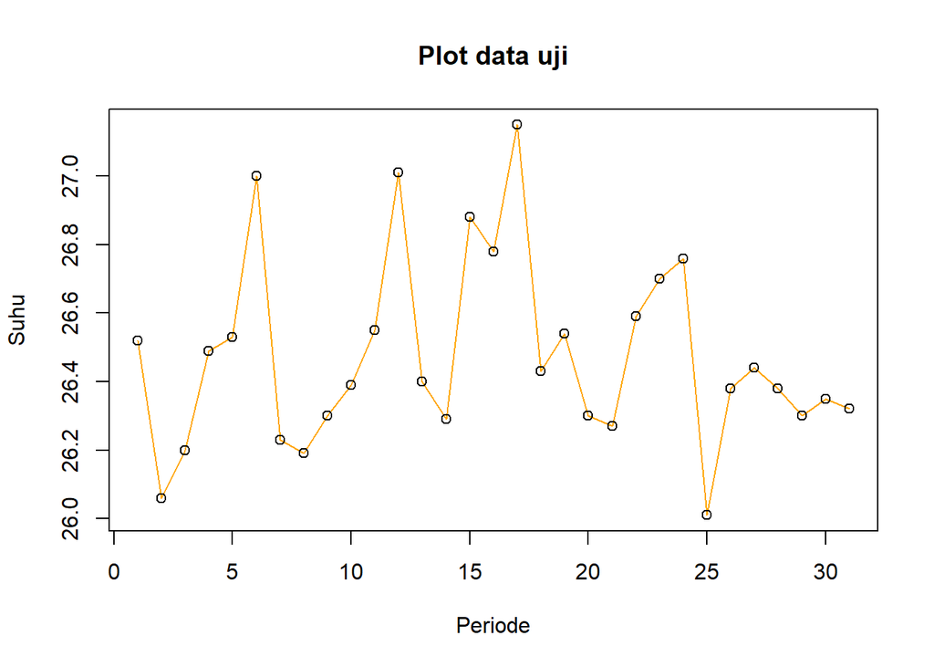

```r
# Data Test
ts.plot(test.ts, col="orange",main="Plot data uji", type="o",xlab="Periode",ylab="Suhu")
points(test.ts)
```

Berdasarkan plot data deret waktu, terlihat bahwa data suhu Lampung cenderung konstan dan bergerak pada nilai tengah tertentu. Hal ini mengindikasikan bahwa data stasioner dalam rataan.

# Uji Stasioneritas Data

### Plot ACF

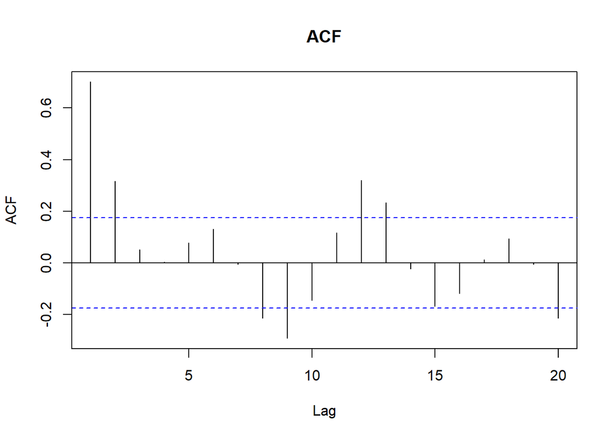

```r
acf(train.ts, main="ACF", lag.max=20)
```

Berdasarkan plot ACF, terlihat bahwa plot ACF pada data tersebut *cuts off* pada lag ke-2 dan membentuk gelombang sinus. Hal ini menandakan bahwa data tersebut stasioner dalam rataan.

### Uji ADF

```r
tseries::adf.test(train.ts)
```

```
##
##  Augmented Dickey-Fuller Test
##
## data:  train.ts
## Dickey-Fuller = -4.0268, Lag order = 4, p-value = 0.01026
## alternative hypothesis: stationary
```

$H_0$ : Data tidak stasioner dalam rataan $H_1$ : Data stasioner dalam rataan

Berdasarkan uji ADF tersebut, didapat *p-value* sebesar 0.01026 yang lebih kecil dari taraf nyata 5% sehingga tolak $H_0$ dan menandakan bahwa data stasioner dalam rataan. Hal ini sesuai dengan hasil eksplorasi menggunakan plot time series dan plot ACF.

### Plot Box-Cox

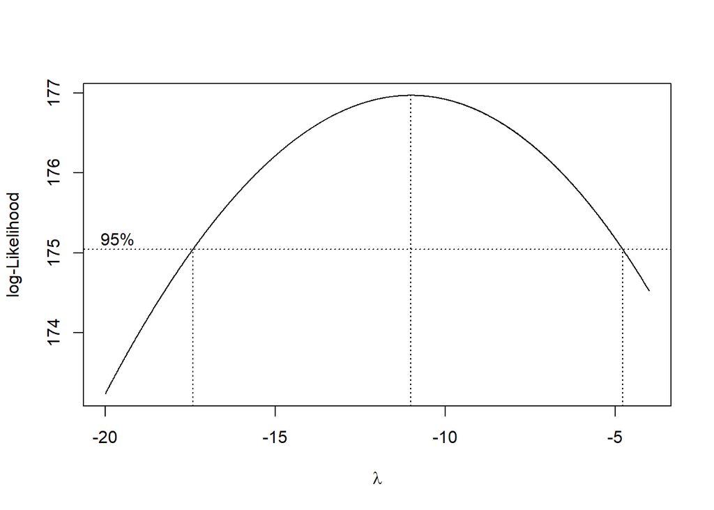

```r
index <- seq(1:125)
bc = boxcox(train.ts~index, lambda = seq(-20,-4,by=0.01))
```

```r
#Nilai Rounded Lambda
lambda <- bc$x[which.max(bc$y)]
lambda
```

```
## [1] -11.01
```

```r
#SK
bc$x[bc$y > max(bc$y) - 1/2 * qchisq(.95,1)]
```

[output not shown]

[output cut: 112 more lines]

```r
tail(bc$x[bc$y > max(bc$y) - 1/2 * qchisq(.95,1)])
```

```
## [1] -4.84 -4.83 -4.82 -4.81 -4.80 -4.79
```

#Transformasi Data

```r
datatrans <- 1/((data.ts)^11)
datatrans
```

```
## Time Series:
## Start = 1
## End = 156
## Frequency = 1
##   [1] 2.442070e-16 1.881487e-16 1.944174e-16 1.678858e-16 1.741264e-16
##   [6] 2.401523e-16 2.667565e-16 2.600905e-16 2.255888e-16 2.589972e-16
##  [11] 2.622921e-16 3.507104e-16 3.301414e-16 2.830469e-16 2.978758e-16
##  [16] 2.391502e-16 2.182178e-16 2.371595e-16 2.431864e-16 1.741264e-16
##  [21] 1.423846e-16 1.530185e-16 1.493806e-16 1.769809e-16 2.622921e-16
##  [26] 2.342074e-16 2.514835e-16 2.442070e-16 1.873807e-16 2.255888e-16
##  [31] 1.992684e-16 1.505826e-16 1.511876e-16 1.517952e-16 1.505826e-16
##  [36] 2.200356e-16 2.736093e-16 2.546741e-16 1.928291e-16 2.137447e-16
##  [41] 2.025756e-16 2.312952e-16 3.004287e-16 2.747700e-16 1.968266e-16
##  [46] 1.769809e-16 2.411590e-16 2.557475e-16 2.966083e-16 2.759361e-16
##  [51] 2.076494e-16 2.164164e-16 1.835919e-16 2.137447e-16 2.312952e-16
```

[output cut: 21 more lines]

```r
dataaa <- datatrans^(-1/11)
dataaa
```

```
## Time Series:
## Start = 1
## End = 156
## Frequency = 1
##   [1] 26.26 26.89 26.81 27.17 27.08 26.30 26.05 26.11 26.45 26.12 26.09 25.41
##  [13] 25.55 25.91 25.79 26.31 26.53 26.33 26.27 27.08 27.58 27.40 27.46 27.04
##  [25] 26.09 26.36 26.19 26.26 26.90 26.45 26.75 27.44 27.43 27.42 27.44 26.51
##  [37] 25.99 26.16 26.83 26.58 26.71 26.39 25.77 25.98 26.78 27.04 26.29 26.15
##  [49] 25.80 25.97 26.65 26.55 26.95 26.58 26.39 26.64 27.70 28.37 27.29 26.21
##  [61] 26.00 26.15 26.41 26.55 26.59 26.24 26.48 27.25 27.73 28.49 28.74 27.21
##  [73] 27.26 26.83 27.30 27.16 27.23 26.73 26.47 26.54 26.74 26.25 26.65 26.33
##  [85] 26.18 25.96 26.38 26.40 26.83 26.38 26.15 26.59 27.74 27.39 27.08 26.41
##  [97] 26.15 26.19 26.40 26.79 26.79 26.44 25.76 26.69 27.30 28.15 27.25 26.94
## [109] 26.85 26.87 26.72 27.17 26.95 26.23 26.04 26.76 27.87 28.30 28.48 28.26
## [121] 27.01 26.91 27.00 27.18 27.12 26.52 26.06 26.20 26.49 26.53 27.00 26.23
## [133] 26.19 26.30 26.39 26.55 27.01 26.40 26.29 26.88 26.78 27.15 26.43 26.54
## [145] 26.30 26.27 26.59 26.70 26.76 26.01 26.38 26.44 26.38 26.30 26.35 26.32
```

### Eksplorasi Data

#### Plot Data Penuh

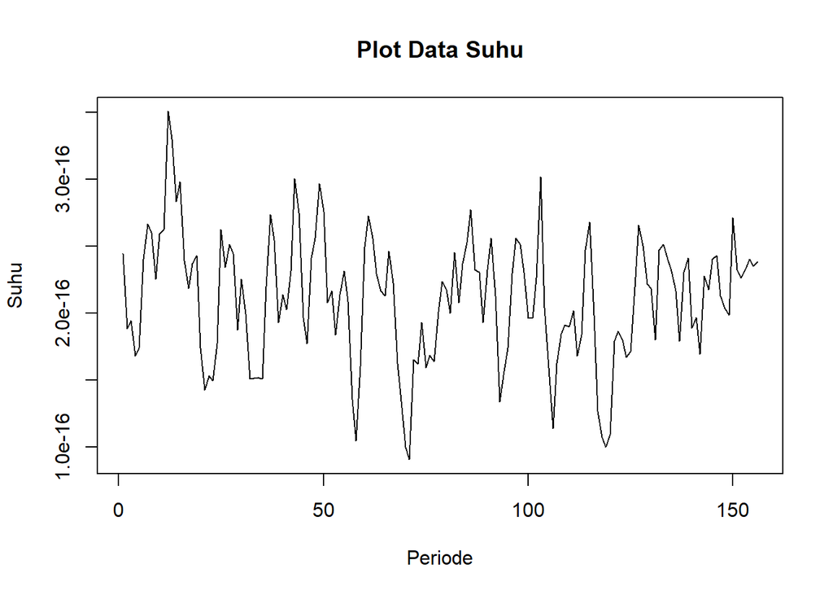

```r
plot.ts(datatrans, lty=1, xlab="Periode", ylab="Suhu", main="Plot Data Suhu")
```

Selanjutnya, akan dilakukan pembagian data latih dan data uji dengan proporsi 80%:20%.

#### Plot Data Latih

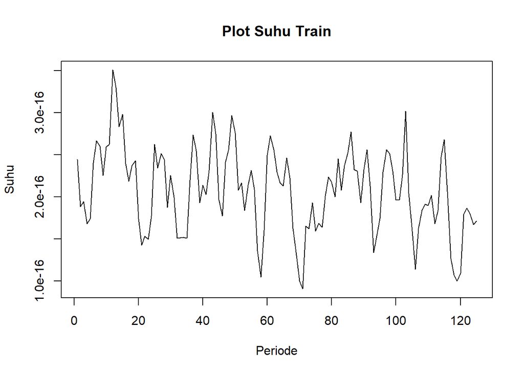

```r
datatrain <- datatrans[1:125]
train.ts <- ts(datatrain)
plot.ts(train.ts, lty=1, xlab="Periode", ylab="Suhu", main="Plot Suhu Train")
```

#### Plot Data Uji

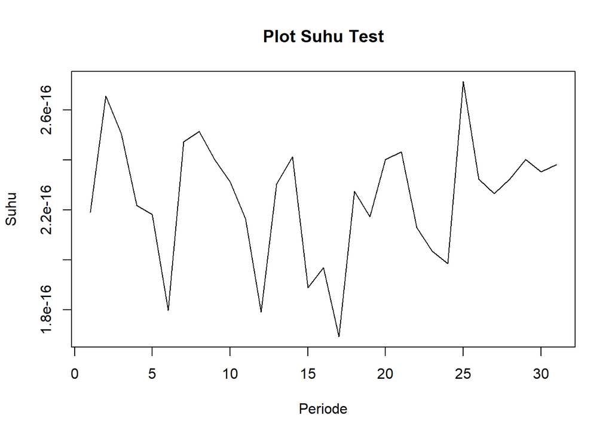

```r
datatest<-datatrans[126:156]
test.ts<-ts(datatest)
plot.ts(test.ts, lty=1, xlab="Periode", ylab="Suhu", main="Plot Suhu Test")
```

### Uji Stasioneritas Data

#### Plot ACF

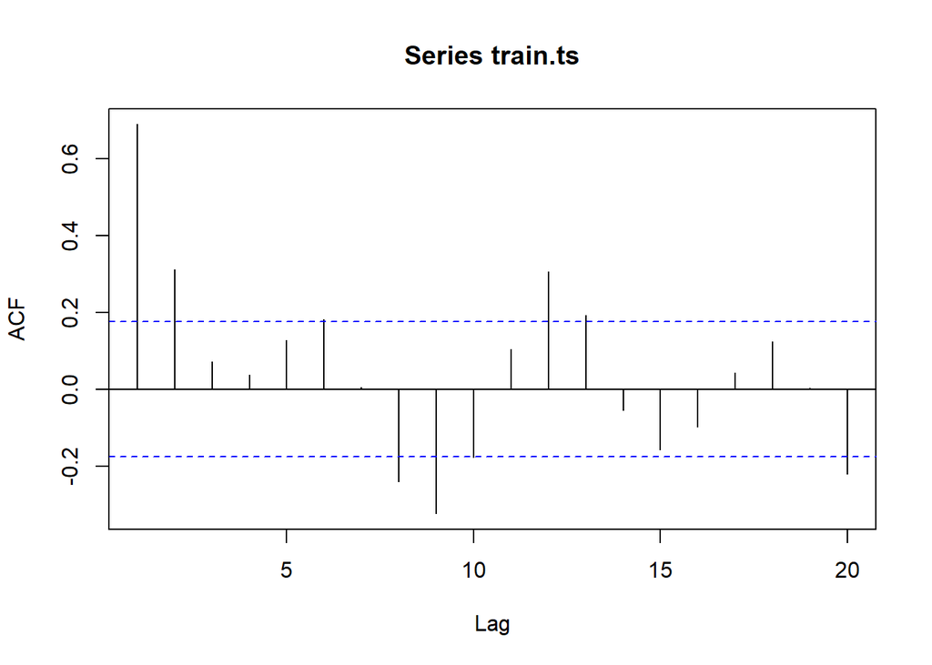

```r
acf(train.ts)
```

Berdasarkan plot ACF, terlihat bahwa plot ACF pada data tersebut *cuts off* pada lag ke-2 dan membentuk gelombang sinus. Hal ini menandakan bahwa data tersebut stasioner dalam rataan.

#### Uji ADF

```r
tseries::adf.test(train.ts)
```

```
##
##  Augmented Dickey-Fuller Test
##
## data:  train.ts
## Dickey-Fuller = -3.8702, Lag order = 4, p-value = 0.01787
## alternative hypothesis: stationary
```

$H_0$ : Data tidak stasioner dalam rataan

$H_1$ : Data stasioner dalam rataan

Berdasarkan uji ADF tersebut, didapat *p-value* sebesar 0.01787 yang lebih kecil dari taraf nyata 5% sehingga tolak $H_0$ dan menandakan bahwa data stasioner dalam rataan. Hal ini sesuai dengan hasil eksplorasi menggunakan plot time series dan plot ACF.

#### Plot Box-Cox

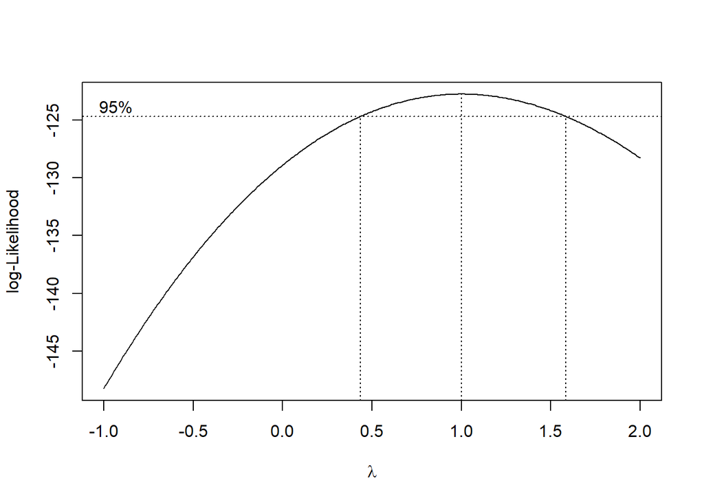

```r
index <- seq(1:125)
bc = boxcox(train.ts~index, lambda = seq(-1,2,by=0.01))
```

```r
#Nilai Rounded Lambda
lambda <- bc$x[which.max(bc$y)]
lambda
```

```
## [1] 1
```

```r
#SK
bc$x[bc$y > max(bc$y) - 1/2 * qchisq(.95,1)]
```

```
##   [1] 0.44 0.45 0.46 0.47 0.48 0.49 0.50 0.51 0.52 0.53 0.54 0.55 0.56 0.57 0.58
##  [16] 0.59 0.60 0.61 0.62 0.63 0.64 0.65 0.66 0.67 0.68 0.69 0.70 0.71 0.72 0.73
##  [31] 0.74 0.75 0.76 0.77 0.78 0.79 0.80 0.81 0.82 0.83 0.84 0.85 0.86 0.87 0.88
##  [46] 0.89 0.90 0.91 0.92 0.93 0.94 0.95 0.96 0.97 0.98 0.99 1.00 1.01 1.02 1.03
##  [61] 1.04 1.05 1.06 1.07 1.08 1.09 1.10 1.11 1.12 1.13 1.14 1.15 1.16 1.17 1.18
##  [76] 1.19 1.20 1.21 1.22 1.23 1.24 1.25 1.26 1.27 1.28 1.29 1.30 1.31 1.32 1.33
##  [91] 1.34 1.35 1.36 1.37 1.38 1.39 1.40 1.41 1.42 1.43 1.44 1.45 1.46 1.47 1.48
## [106] 1.49 1.50 1.51 1.52 1.53 1.54 1.55 1.56 1.57 1.58
```

```r
tail(bc$x[bc$y > max(bc$y) - 1/2 * qchisq(.95,1)])
```

```
## [1] 1.53 1.54 1.55 1.56 1.57 1.58
```

Gambar di atas menunjukkan nilai *rounded value* ($\lambda$) optimum sebesar **1.00** dan pada selang kepercayaan 95% nilai memiliki batas bawah **0.44** dan batas atas **1.58**. Selang tersebut memuat nilai satu sehingga dapat dikatakan bahwa data stasioner dalam ragam.